# Download and work with NEON Aquatic Instrument Data

## Filtering (Some) Quality Flagged Observations

A simple approach to removing quality flagged observations is to remove data when the finalQF is raised. Let’s view fDOM in the context of its final quality flags:

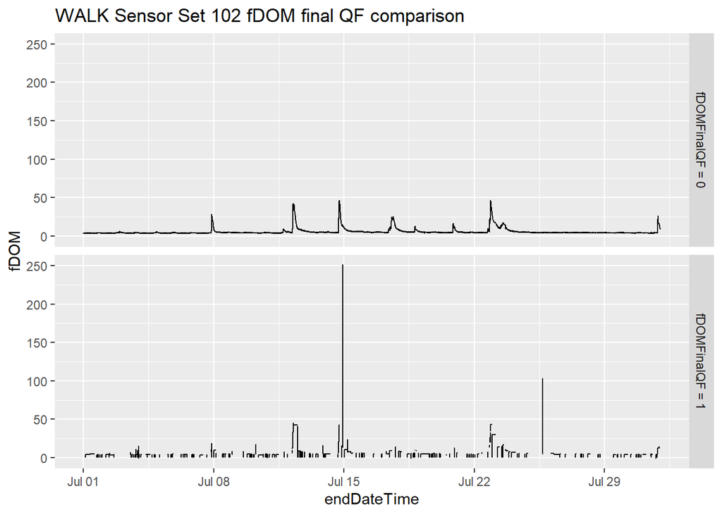

```r
# Map QF label names for the plot for the fDOMFinalQF grouping
group_labels <- c("fDOMFinalQF = 0", "fDOMFinalQF = 1")
names(group_labels) <- c("0","1")

# Plot fDOM data, grouping by the fDOMFinalQF value
ggplot2::ggplot(data = waq_down,
                aes(x = endDateTime, y = fDOM, group = fDOMFinalQF)) +
  ggplot2::geom_step() +
  facet_grid(fDOMFinalQF ~ .,
             labeller = labeller(fDOMFinalQF = group_labels)) +
  ggplot2::ggtitle("WALK Sensor Set 102 fDOM final QF comparison")
```

The top panel corresponding to `fDOMFinalQF = 0` represents all fDOM data that were not flagged. Conversely, the `fDOMFinalQF = 1` represents all flagged fDOM data. Clearly, many data points that should have been auto flagged were (example NAs). But also, a few data points that perhaps shouldn’t have been were (example steps during the rising limb of storms). Also note that the automated quality flag algorithms are not perfect, and suspect data points may occasionally pass the quality tests.

Rather than relying on the `FinalQF` column to omit any quality flags, we encourage users to download the expanded data package (which contains individual QF) and determine for themselves which data points to include or omit.

## Data Aggregation

Sensor data users commonly wish to aggregate data across two different datasets. In the following example, we will show how to combine fDOM from the water quality (DP1.20288.001) data product and continuous discharge (DP4.00130.001) into a single dataframe.

```r
# First, we want to subset all of the data related to fDOM.  We can do this
# using a grep function to target all the column names containing "fDOM".
# The timestamp (which we need to aggregate) is shared by all data in
# water quality and does not have "fDOM" in the name, so we must first add it.
names(waq_down)[names(waq_down) == "endDateTime"] <- "fDOMendDate"
fDOM <- waq_down[,grep("fDOM",names(waq_down))]

# We may also want to remove any quality flagged measurements.
fDOM<-fDOM[(fDOM$fDOMFinalQF==0),]
# And lets do the same thing for continuous discharge.
csd_continuousDischarge<-csd_continuousDischarge[(csd_continuousDischarge$dischargeFinalQF==0),]
```

Next we need to ensure that the time stamps will match correctly.

```r
# Let's check to make sure our time columns are in POSIXct format, which is
# needed if you download and read-in NEON data files without using the
# neonUtilities package.
if("POSIXct" %in% class(fDOM$fDOMendDate)){
  print("Time column in fDOM is appropriately in POSIXct format")
} else {
  print("Converting fDOM endDate column to POSIXct")
  fDOM$fDOMendDate <- as.POSIXct(fDOM$fDOMendDate, tz = "UTC")
}
```

```
## [1] "Time column in fDOM is appropriately in POSIXct format"
```

```r
if("POSIXct" %in% class(csd_continuousDischarge$endDate)){
  print("Time column in csd_continuousDischarge is appropriately in POSIXct format")
} else {
  print("Converting csd_continuousDischarge column to POSIXct")
  csd_continuousDischarge$endDate <- as.POSIXct(csd_continuousDischarge$endDate, tz = "UTC")
}
```

```
## [1] "Time column in csd_continuousDischarge is appropriately in POSIXct format"
```

```r
#  Water quality and continuous discharge are both reported in 1 minute
# intervals.  But we still need to ensure that the time stamps will be an
# exact match by rounding them to the nearest minute. We can do this using
# the lubridate package.
fDOM$fDOMendDate<-lubridate::round_date(fDOM$fDOMendDate,unit="1 minute")
csd_continuousDischarge$endDate<-lubridate::round_date(csd_continuousDischarge$endDate,unit="1 minute")
```

Now we can merge the dataframes.

```r
# In this case we are only interested in paired measurements. To retain all
# measurements even if there is not a corresponding measurement in the other
# dataframe, change all.x & all.y to TRUE.
mergedData<-merge(fDOM,csd_continuousDischarge,by.x="fDOMendDate",by.y="endDate",all.x=F,all.y=F)
```

Let’s take a look at a plot of fDOM versus discharge

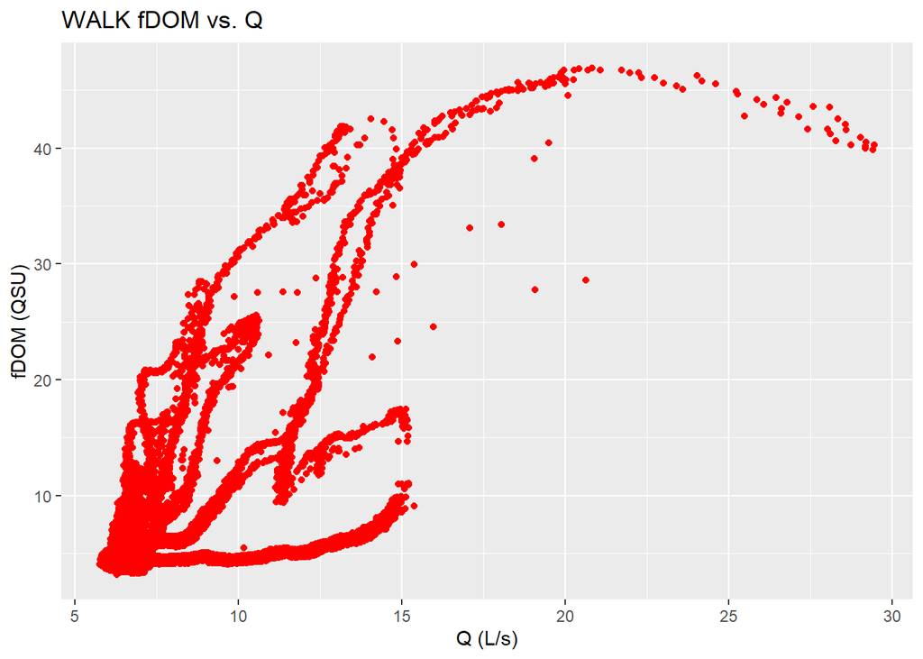

```r
ggplot(data = mergedData,
       aes(x = maxpostDischarge, y = fDOM)) +
  geom_point(color="red") +
  ggtitle("WALK fDOM vs. Q") +
  xlab("Q (L/s)") +
  ylab("fDOM (QSU)")
```

### Challenge: Aggregate nitrate and continuous discharge

Using what you’ve learned above, can you modify the code to aggregate nitrate and continuous discharge? Remember, nitrate is reported as a 15 minute average, and there are a couple potential ways of dealing with this.

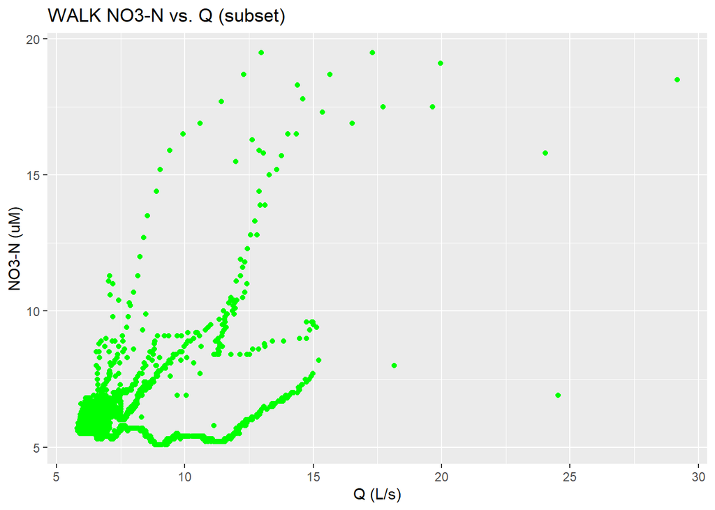

```r
# First let's remove any quality flagged measurements
NSW_15_minute<-NSW_15_minute[(NSW_15_minute$finalQF==0),]

# Round the nitrate time stamp to the nearest minute
NSW_15_minute$endDateTime<-lubridate::round_date(NSW_15_minute$endDateTime,unit="1 minute")

# Merge the dataframes using the time stamps.  A simple approach is matching
# every 15th discharge measurement with the corresponding nitrate measurement
# and discarding the rest.
mergedData2<-merge(NSW_15_minute,csd_continuousDischarge,
                   by.x="endDateTime",by.y="endDate",
                   all.x=F,all.y=F)

# An alternative approach would be to first convert the csd dataframe into
# 15 minute averages.
csd_15_minute<-csd_continuousDischarge[,c("endDate","maxpostDischarge")]
csd_15_minute$endDate<-lubridate::round_date(csd_15_minute$endDate,unit="15 minute")
csd_15_minute<-plyr::ddply(csd_15_minute,c("endDate"),summarise,maxpostDischarge=mean(maxpostDischarge))
mergedData2b<-merge(NSW_15_minute,csd_15_minute,by.x="endDateTime",by.y="endDate",all.x=F,all.y=F)

ggplot(data = mergedData2,
       aes(x = maxpostDischarge, y = surfWaterNitrateMean)) +
  geom_point(color="green") +
  ggtitle("WALK NO3-N vs. Q (subset)") +
  xlab("Q (L/s)") +
  ylab("NO3-N (uM)")
```

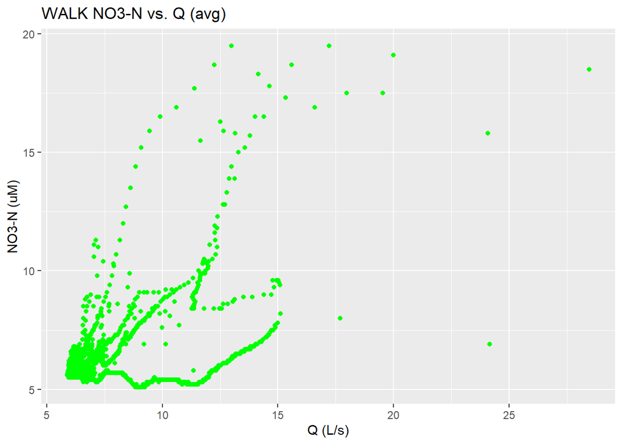

```r
ggplot(data = mergedData2b,
       aes(x = maxpostDischarge, y = surfWaterNitrateMean)) +
  geom_point(color="green") +
  ggtitle("WALK NO3-N vs. Q (avg)") +
  xlab("Q (L/s)") +
  ylab("NO3-N (uM)")
```

Now that you have the basic tools and knowledge on how to read and wrangle NEON AIS data, go have fun working on your scientific questions!